# Bank Marketing - Modeling

Ming Ming Zhang

## 1. Packages

```r
library(rminer)
library(rpart)
source("~/Downloads/bank-additional/evaluation.R")
```

## 2. Evaluation

```r
D = read.table("bank-additional-full.csv", header=TRUE, sep=";")
str(D)
```

```
'data.frame':   41188 obs. of  21 variables:
 $ age           : int  56 57 37 40 56 45 59 41 24 25 ...
 $ job           : Factor w/ 12 levels "admin.","blue-collar",..: 4 8 8 1 8 8 1 2 10 8 ...
 $ marital       : Factor w/ 4 levels "divorced","married",..: 2 2 2 2 2 2 2 2 3 3 ...
 $ education     : Factor w/ 8 levels "basic.4y","basic.6y",..: 1 4 4 2 4 3 6 8 6 4 ...
 $ default       : Factor w/ 3 levels "no","unknown",..: 1 2 1 1 1 2 1 2 1 1 ...
 $ housing       : Factor w/ 3 levels "no","unknown",..: 1 1 3 1 1 1 1 1 3 3 ...
 $ loan          : Factor w/ 3 levels "no","unknown",..: 1 1 1 1 3 1 1 1 1 1 ...
 $ contact       : Factor w/ 2 levels "cellular","telephone": 2 2 2 2 2 2 2 2 2 2 ...
 $ month         : Factor w/ 10 levels "apr","aug","dec",..: 7 7 7 7 7 7 7 7 7 7 ...
 $ day_of_week   : Factor w/ 5 levels "fri","mon","thu",..: 2 2 2 2 2 2 2 2 2 2 ...
 $ duration      : int  261 149 226 151 307 198 139 217 380 50 ...
 $ campaign      : int  1 1 1 1 1 1 1 1 1 1 ...
 $ pdays         : int  999 999 999 999 999 999 999 999 999 999 ...
 $ previous      : int  0 0 0 0 0 0 0 0 0 0 ...
 $ poutcome      : Factor w/ 3 levels "failure","nonexistent",..: 2 2 2 2 2 2 2 2 2 2 ...
 $ emp.var.rate  : num  1.1 1.1 1.1 1.1 1.1 1.1 1.1 1.1 1.1 1.1 ...
 $ cons.price.idx: num  94 94 94 94 94 ...
 $ cons.conf.idx : num  -36.4 -36.4 -36.4 -36.4 -36.4 -36.4 -36.4 -36.4 -36.4 -36.4 ...
 $ euribor3m     : num  4.86 4.86 4.86 4.86 4.86 ...
 $ nr.employed   : num  5191 5191 5191 5191 5191 ...
 $ y             : Factor w/ 2 levels "no","yes": 1 1 1 1 1 1 1 1 1 1 ...
```

### 2.1. Metric

Since the response variable `y` is imbalanced, the $F_1$ score and AUC metric will be used.

```r
table(D$y)
```

```
   no   yes
36548  4640
```

```r
paste("Subscribed ratio:", round(table(D$y)[2] / sum(table(D$y)), 2)*100, "%")
```

```
[1] "Subscribed ratio: 11 %"
```

### 2.2 Train/Dev/Test

For later training purpose, we normalize the data.

```r
normalizedD = D

intL = c()
for (x in names(D)) {
  if (class(D[,x])=="integer" | class(D[,x])=="numeric") {
    normalizedD[,x] = (D[,x] - mean(D[,x])) / sd(D[,x])
    intL = c(intL, x, mean(D[,x]), sd(D[,x]))
  }
}

mat_intL = matrix(intL, nrow = 10, ncol = 3, byrow = T)
colnames(mat_intL) = c("feature", "mean", "sd")
df_intL = data.frame(mat_intL, stringsAsFactors = F)
df_intL$mean = as.numeric(df_intL$mean)
df_intL$sd = as.numeric(df_intL$sd)
df_intL
```

| feature | mean | sd |
| --- | --- | --- |
| age | 40.0240604 | 10.4212500 |
| duration | 258.2850102 | 259.2792488 |
| campaign | 2.5675925 | 2.7700135 |
| pdays | 962.4754540 | 186.9109073 |
| previous | 0.1729630 | 0.4949011 |
| emp.var.rate | 0.0818855 | 1.5709597 |
| cons.price.idx | 93.5756644 | 0.5788400 |
| cons.conf.idx | -40.5026003 | 4.6281979 |
| euribor3m | 3.6212908 | 1.7344474 |
| nr.employed | 5167.0359109 | 72.2515277 |

Since the dataset has large number of examples and the splitting train/dev/test ratio 0.9/0.05/0.05 shows high variance between the dev and test set, the ratio 0.8/0.1/0.1 will be used.

```r
set.seed(1)

D1 = splitData(D)
normalizedD1 = splitData(normalizedD)

XY_train = D1[[1]]
XY_dev = D1[[2]]
XY_test = D1[[3]]

nXY_train = normalizedD1[[1]]
nXY_dev = normalizedD1[[2]]
nXY_test = normalizedD1[[3]]
```

Note that both dev and test set do not contain `default` example.

```r
table(XY_train$default)
```

```
     no unknown     yes
  26057    6890       3
```

```r
table(XY_dev$default)
```

```
     no unknown     yes
   3303     816       0
```

```r
table(XY_test$default)
```

```
     no unknown     yes
   3228     891       0
```

## 3. Modeling

We will use models: decision tree, logistic regression and neural networks.

For later training purpose, we combine train and dev set into one train set.

```r
rminerD1 = rbind.data.frame(XY_train, XY_dev)
rminerD2 = rbind.data.frame(nXY_train, nXY_dev)
```

### 3.1 Decision Tree

The decision tree will be applied by the package `rminer` of `R`. The model uses the holdout method on the combined train/dev (`rminerD1`) set with further splitting 0.8/0.2 ratio, repeated 20 times.

```r
dt1 = mining(y~., rminerD1, method=c("holdout", 0.8), model="dt", Runs=20)
res_dt1 = mmetric(dt1, metric = c("F1", "AUC"))
df_dt1 = data.frame("F1"=mean(res_dt1[,2])/100, "AUC"=mean(res_dt1[,3]))
row.names(df_dt1) = "Decision Tree"
df_dt1
```

|  | F1 | AUC |
| --- | --- | --- |
| Decision Tree | 0.5598437 | 0.8484796 |

### 3.2 Logistic Regression

The logistic regression will be applied by the package `rminer` of `R`. The model uses the holdout method on the combined train/dev (`rminerD2`) set with further splitting 0.8/0.2 ratio, repeated 20 times.

```r
lr1 = mining(y~., rminerD2, method=c("holdout", 0.8), model="lr", Runs=20)
res_lr1 = mmetric(lr1, metric = c("F1", "AUC"))
df_lr1 = data.frame("F1"=mean(res_lr1[,2])/100, "AUC"=mean(res_lr1[,3]))
row.names(df_lr1) = "Logistic Regression"
df_lr1
```

|  | F1 | AUC |
| --- | --- | --- |
| Logistic Regression | 0.5012584 | 0.9315081 |

### 3.3 2-Layer Neural Network

The neural network will be applied by the package `rminer` of `R`. In particular, the model is a single hidden layer (or 2-layer) neural network with 6 units and 7 ensembles used BFGS Quasi-Newton optimizer. The model uses the holdout method on the combined train/dev (`rminerD2`) set with further splitting 0.8/0.2 ratio, repeated 20 times.

```r
nn1 = mining(y~., rminerD2, method=c("holdout", 0.8), model="mlp", size = 6, nr = 7, maxit = 500, Runs=20)
res_nn1 = mmetric(nn1, metric = c("F1", "AUC"))
df_nn1 = data.frame("F1"=mean(res_nn1[,2])/100, "AUC"=mean(res_nn1[,3]))
row.names(df_nn1) = "2-Layer Neural Network"
df_nn1
```

|  | F1 | AUC |
| --- | --- | --- |
| 2-Layer Neural Network | 0.5707004 | 0.9347846 |

### 3.4 3-Layer Neural Network

The neural network will be applied by the package `nn_model_np` implemented by the author in `Python`. In particular, the model (after tuning) is an 2 hidden layer (or 3-layer) neural network with 5 and 2 units, respectively, with relu-relu-sigmoid activation functions used gradient descent with momentum optimizer (0.3 learning rate, 0.9 moving average rate, 32 mini-batch size and 500 epochs). The model is trained on the train set (`nXY_train`).

Before training, we need to convert the data in the format used in `nn_model_np` of `Python`. For training in `Python`, code can be found in [here](https://github.com/DrMMZ/drmmz.github.io/blob/master/bank.ipynb).

```r
library(caret)

dmy = dummyVars(" ~ .", data = nXY_train[, names(nXY_train)!="y"], fullRank = T)
X_train = data.frame(predict(dmy, newdata = nXY_train[, names(nXY_train)!="y"]))
Y_train = nXY_train[, names(nXY_train)=="y"]
Y_train = as.numeric(Y_train) - 1

dmy = dummyVars(" ~ .", data = nXY_dev[, names(nXY_dev)!="y"], fullRank = T)
X_dev = data.frame(predict(dmy, newdata = nXY_dev[, names(nXY_dev)!="y"]))
Y_dev = nXY_dev[, names(nXY_dev)=="y"]
Y_dev = as.numeric(Y_dev) - 1

dmy = dummyVars(" ~ .", data = nXY_test[, names(nXY_test)!="y"], fullRank = T)
X_test = data.frame(predict(dmy, newdata = nXY_test[, names(nXY_test)!="y"]))
Y_test = nXY_test[, names(nXY_test)=="y"]
Y_test = as.numeric(Y_test) - 1

write.csv(X_train, "~/Downloads/bank-additional/X_train.csv")
write.csv(Y_train, "~/Downloads/bank-additional/Y_train.csv")
write.csv(X_dev, "~/Downloads/bank-additional/X_dev.csv")
write.csv(Y_dev, "~/Downloads/bank-additional/Y_dev.csv")
write.csv(X_test, "~/Downloads/bank-additional/X_test.csv")
write.csv(Y_test, "~/Downloads/bank-additional/Y_test.csv")
```

The performance on the dev set is shown as follow.

```r
df_nn2 = data.frame("precision"=0.5702746, "recall"=0.7354167, "F1"=0.6424022)
row.names(df_nn2) = "3-Layer Neural Network"
df_nn2
```

|  | precision | recall | F1 |
| --- | --- | --- | --- |
| 3-Layer Neural Network | 0.5702746 | 0.7354167 | 0.6424022 |

### 3.5 Final Model

The best model is given by the 3-Layer Neural Network as the performance on the dev set is the highest in $F_1$ score $0.642$.

```r
df_nn2_1 = data.frame("F1"=0.6424022, "AUC"=NA)
row.names(df_nn2_1) = "3-Layer Neural Network"

df_res = rbind.data.frame(df_dt1, df_lr1, df_nn1, df_nn2_1)
df_res
```

|  | F1 | AUC |
| --- | --- | --- |
| Decision Tree | 0.5598437 | 0.8484796 |
| Logistic Regression | 0.5012584 | 0.9315081 |
| 2-Layer Neural Network | 0.5707004 | 0.9347846 |
| 3-Layer Neural Network | 0.6424022 | NA |

The ROC curves of the models Decision Tree (DT-1), Logistic Regression (LR-1) and 2-Layer Neural Network (NN-1) is shown below.

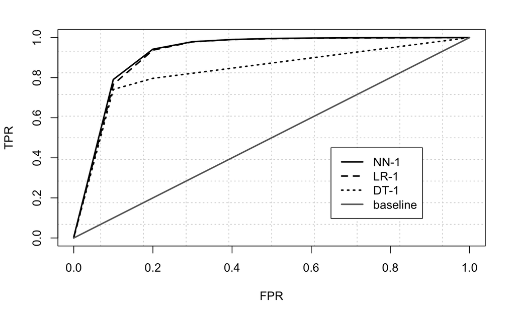

```r
L = vector("list", 3); L[[1]] = nn1; L[[2]] = lr1; L[[3]] = dt1
mgraph(L, graph="ROC", leg=c("NN-1","LR-1","DT-1"), Grid=10, baseline=TRUE, intbar = F)
```

The performance of the 3-Layer Neural Network on the test set is:

```r
df_nn2_2 = data.frame("precision"=0.5711948, "recall"=0.7240664, "F1"=0.6386093)
row.names(df_nn2_2) = "3-Layer Neural Network"
df_nn2_2
```

|  | precision | recall | F1 |
| --- | --- | --- | --- |
| 3-Layer Neural Network | 0.5711948 | 0.7240664 | 0.6386093 |

## 4. Feature Importance

We use decision tree to measure feature importance and the ranking (in decreasing order) is listed below. The top 3 categories of important features are phone call duration, social and economic indicators and contact month of year.

```r
dt = rpart(y~., data = XY_train)
dt_impVars = dt$variable.importance
names(dt_impVars)
```

```
 [1] "duration"       "nr.employed"    "euribor3m"      "emp.var.rate"   "cons.conf.idx"  "cons.price.idx" "month"
 [8] "pdays"          "poutcome"       "previous"       "campaign"       "job"            "age"            "education"
[15] "marital"
```

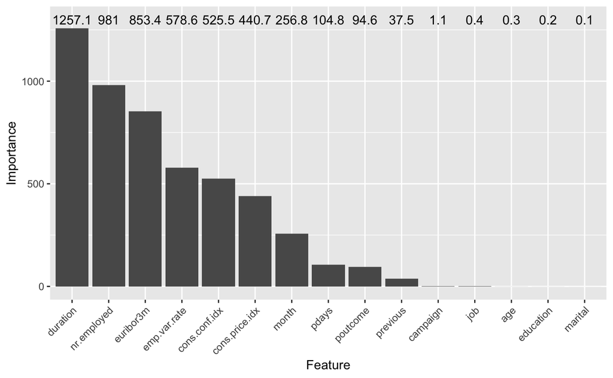

```r
df_impVars = data.frame("feature"=names(dt_impVars), "value"=round(dt_impVars,1), row.names = NULL)

ggplot(df_impVars, aes(x=reorder(feature,-value), y=value)) +
  geom_bar(stat="identity") +
  annotate("text", x = 1:length(dt_impVars), y=1300, label = sort(df_impVars$value, decreasing = T)) +
  theme(axis.text.x = element_text(angle=45, hjust=1)) +
  xlab("Feature") + ylab("Importance")# + ggtitle("Feature Importance by Decision Tree")

ggsave(filename = "~/Downloads/bank-additional/fig8.png")
```

## 5. Insights

By using a certain splitting ratio and more complex model 3-layer neural network, we are able to improve the results in [Table 3, Moro et al., 2014](http://dx.doi.org/10.1016/j.dss.2014.03.001).

The decision tree model was applied to reveal several key features, e.g., phone call duration, social and economic indicators (employment rate and euribor rate) and contact month of year.